```python
import numpy as np
from mpl_toolkits.mplot3d import axes3d
import matplotlib.pyplot as plt
%matplotlib inline
```

# Изначальная программа

```
#include <math.h>
#include <stdlib.h>
#include <stdio.h>
#include <omp.h>
#define  Max(a,b) ((a)>(b)?(a):(b))

#define  N   (2*2*2*2*2*2*2*2*2+2)
float   maxeps = 0.1e-7;
int itmax = 100;
int i,j,k;
float eps;
float A [N][N][N],  B [N][N][N];
float start, end;

void relax();
void resid();
void init();
void verify();

int main(int an, char **as)
{
    int it;
    init();
    start = omp_get_wtime();
    for(it=1; it<=itmax; it++)
    {
        eps = 0.;
        relax();
        resid();
        //printf( "it=%4i   eps=%f\n", it,eps);
        if (eps < maxeps) break;
    }
    verify();
    end = omp_get_wtime();
    printf("Elapsed time: %f\nUsed threads: %d\n", end - start, omp_get_max_threads());
    return 0;
}

void init()
{
    for(k=0; k<=N-1; k++)
    for(j=0; j<=N-1; j++)
    for(i=0; i<=N-1; i++)
    {
        if(i==0 || i==N-1 || j==0 || j==N-1 || k==0 || k==N-1) A[i][j][k]= 0.;
        else A[i][j][k]= ( 4. + i + j + k) ;
    }
}

void relax()
{
    for(k=2; k<=N-3; k++)
    for(j=2; j<=N-3; j++)
    for(i=2; i<=N-3; i++)
    {
        B[i][j][k]=(A[i-1][j][k]+A[i+1][j][k]+A[i][j-1][k]+A[i][j+1][k]+A[i][j][k-1]+A[i][j][k+1]+
            A[i-2][j][k]+A[i+2][j][k]+A[i][j-2][k]+A[i][j+2][k]+A[i][j][k-2]+A[i][j][k+2])/12.;
    }
}

void resid()
{
    for(k=1; k<=N-2; k++)
    for(j=1; j<=N-2; j++)
    for(i=1; i<=N-2; i++)
    {
        float e;
        e = fabs(A[i][j][k] - B[i][j][k]);
        A[i][j][k] = B[i][j][k];
        eps = Max(eps,e);
    }
}

void verify()
{
    float s;
    s=0.;
    for(k=0; k<=N-1; k++)
    for(j=0; j<=N-1; j++)
    for(i=0; i<=N-1; i++)
    {
        s=s+A[i][j][k]*(i+1)*(j+1)*(k+1)/(N*N*N);
    }
    printf("  S = %f\n",s);
}
```

Первое, что можно заметить - неправильный порядок обхода массива. Матрицы А и В хранятся построчно, то есть, сначала в массиве А идут элементы A[0][0][0] - A[0][0][N], затем A[0][1][0] - A[0][1][N], и так далее. Соответственно, для правильного использования кэширования в процессорах нужно итерировать A[i][j][k] в порядке i - j - k.  
Тестирование на кластере Polus показывает, что изначальная однопоточная версия при $N=2^9+2$ исполняется 1227 секунд, а версия с перестановкой циклов - 56 секунд (здесь и далее, если не указано обратное, подразумевается компиляция в gcc с уровнем оптимизации -O3). Далее будем работать только с "правильным" обходом циклов.

Анализ однопоточной программы утилитой perf показывает, что функции `init()` и `verify()` занимают в сумме примерно 1.5% времени работы программы. Их мы распараллеливать не будем, распараллелим `relax()` и `resid()`.

# OpenMP. Версия с использованием parallel for

```
#include <math.h>
#include <stdlib.h>
#include <stdio.h>
#include <omp.h>
#define  Max(a,b) ((a)>(b)?(a):(b))

#define  N   (2*2*2*2*2*2*2*2*2+2)
float   maxeps = 0.1e-7;
int itmax = 100;
int i, j, k;
float eps;
float A [N][N][N],  B [N][N][N];

void relax();
void resid();
void init();
void verify();

int main(int an, char **as)
{
    int it;
    double start, end;
    init();
    start = omp_get_wtime();
    for(it=1; it<=itmax; it++)
    {
        eps = 0.;
        relax();
        resid();
        //printf( "it=%4i   eps=%f\n", it,eps);
        if (eps < maxeps) break;
    }
    verify();
    end = omp_get_wtime();
    printf("Elapsed time: %f\nUsed threads: %d\n", end - start, omp_get_max_threads());
    return 0;
}

void init() // Changed iteration order from k-j-i to i-j-k
{
    for(i=0; i<=N-1; i++)
    for(j=0; j<=N-1; j++)
    for(k=0; k<=N-1; k++)
    {
        if(i==0 || i==N-1 || j==0 || j==N-1 || k==0 || k==N-1) A[i][j][k]= 0.;
        else A[i][j][k]= ( 4. + i + j + k) ;
    }
}

void relax() // Changed iteration order from k-j-i to i-j-k
{
    #pragma omp parallel for collapse(2) default(none) \
        private(i, j, k) shared(A, B) // collapse(2) because of vectorization
    for(i=2; i<=N-3; i++)
    for(j=2; j<=N-3; j++)
    for(k=2; k<=N-3; k++)
    {
        B[i][j][k] = (A[i-1][j][k] + A[i+1][j][k] + A[i][j-1][k] + A[i][j+1][k] + A[i][j][k-1] + A[i][j][k+1]+
            A[i-2][j][k] + A[i+2][j][k] + A[i][j-2][k] + A[i][j+2][k] + A[i][j][k-2] + A[i][j][k+2])/12.;
    }
}

void resid() // Changed iteration order from k-j-i to i-j-k
{
    #pragma omp parallel for collapse(2) default(none) \
        private(i, j, k) shared(A, B) reduction(max:eps) // collapse(2) because of vectorization
    for(i=1; i<=N-2; i++)
    for(j=1; j<=N-2; j++)
    for(k=1; k<=N-2; k++)
    {
        float e;
        e = fabs(A[i][j][k] - B[i][j][k]);
        A[i][j][k] = B[i][j][k];
        eps = Max(eps,e);
    }
}

void verify()
{
    float s;
    s=0.;
    for(i=0; i<=N-1; i++)
    for(j=0; j<=N-1; j++)
    for(k=0; k<=N-1; k++)
    {
        s=s+A[i][j][k]*(i+1)*(j+1)*(k+1)/(N*N*N);
    }
    printf("  S = %f\n",s);
}
```

Проведены некоторые исследования. Во-первых, исследуем различные варианты аргумента collapse: 1, 2, 3. Указано время при $N = 2^9 + 2$.  
Программы запускались с разным числом ядер, заданным переменной окружения `OMP_NUM_THREADS` (1, 2, 4, 6, 8, 10, 12, 16, 20, 32, 48, 64, 80, 96, 112, 120, 160). Распределение нитей задаётся переменной окружения `OMP_PLACES`, использование которой сводится к равномерному распределению нитей по ядрам, желательно, находящимся на одном процессоре. Это самый производительный вариант. Всего на кластере Polus 2 процессора по 10 ядер, в каждом - по 8 нитей.  
В некоторых случаях (здесь - collapse(2)) измерение производится несколько раз, за результат берём среднее, чтобы не попасть на какой-то выброс в статистике.  
По оси y шкала логарифмирована.

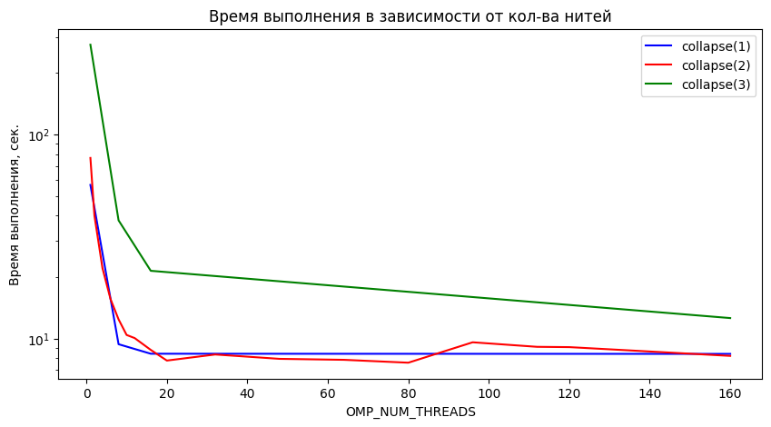

```python
collapses_1()
```

Как видно, лучше всего оставить collapse(2) (на числе нитей между 16 и 160 измерения collapse(1) не проводились; скорее всего, там результаты примерно как у collapse(2)).  
Это происходит из-за того, что gcc сам по возможности векторизует самый вложенный цикл. Если же распараллеливание OpenMP распространяется и на него, то векторизации не будет.  
Попробуем исследовать различные комбинации уровней оптимизации и параметра collapse (графики выше построены для -O3).

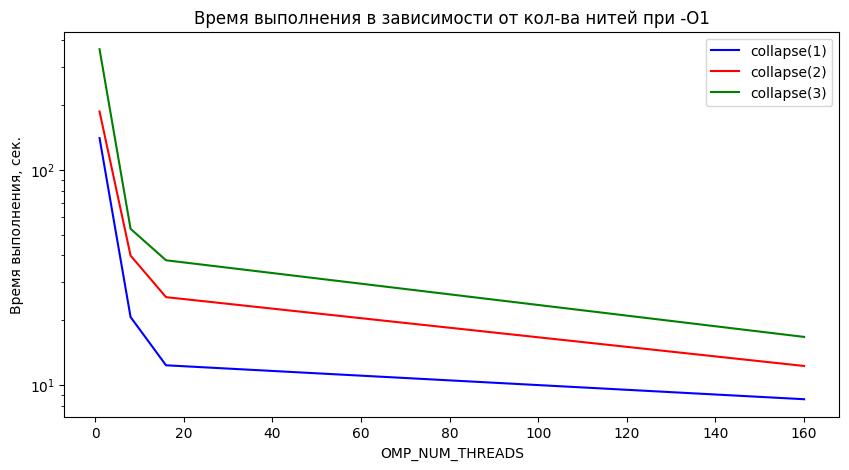

```python
collapses_2()
```

Разница между collapse(2) и collapse(1) даже больше, чем между collapse(2) и collapse(3). Здесь векторизации явно нет. Проверим -О2.

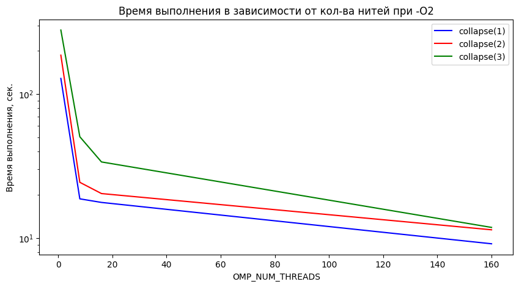

```python
collapses_3()
```

Аналогично. Значит, наверное, векторизация начинает применяться только на -О3. Беглый анализ сгенерированного `gcc` с флажком `-S` кода на языке ассемблера х86 показывает, что при -О3 действительно намного большие инструкций movss в одной итерации, чем при -О2 (там векторные регистры тоже используются, но для вещественной скалярной арифметики).

Рассмотрим зависимость времени выполнения от количества нитей и размера входной матрицы.  
Рассматриваемые $N$: $2^7 + 2$; $2^8 + 2$; $2^9 + 2$ (заданы в коде как `#define N ...`.  
Рассматриваемые `OMP_NUM_THREADS`: 1, 2, 4, 6, 8, 10, 12, 16, 20, 32, 48, 64, 80, 96, 112, 120, 160.  
Код компилируется так: `gcc -O3 -fopenmp var72_omp_for.c`.  
Шкала по оси y логарифмирована.

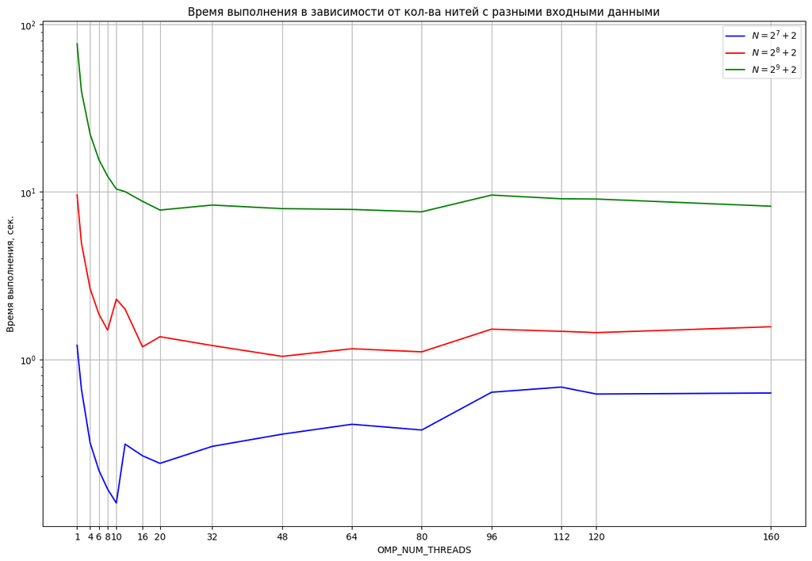

```python
fors()
```

Наблюдения:  
1) Время приблизительно пропорционально количеству элементов в обрабатываемых матрицах (учитываем, что оно кубически зависит от $N$, и что шкала по оси у логарифмическая)  
2) На относительно малых матрицах насыщение происходит на 8-10 нитях. Дальше наращивать их число невыгодно, поскольку накладных расходов на их создание и распределение ресурсов между ними будет больше. При $N = 2^9 + 2$ такое не наблюдается; на тех же значениях там замедляется рост.  
Конкретно 8 или 10 нитей является критической точкой, вероятно, потому что на кластере Polus 10 ядер на одном процессоре.

# OpenMP. Версия с использованием механизма task

Самый очевидный подход при использовании task - отдавать в задачу каждую итерацию какого-нибудь цикла.  
Итераций внутреннего цикла примерно $N^3$, каждая из них и в `relax()`, и в `resid()` исполняет небольшие действия. Это, очевидно, плохой вариант, потому что задач будет очень много, а каждая задача - это накладные расходы на хранение внутренней информации, переменных, создание, планирование нитей и так далее.  
Рассмотрим разбиение на задачи по итерациям внешнего цикла. Заранее можно сказать, что это будет не очень выгодно, потому что задач всё ещё очень много, порядка $N^2$. Код такой реализации:

```
#include <math.h>
#include <stdlib.h>
#include <stdio.h>
#include <string.h>
#include <omp.h>
#define  Max(a,b) ((a)>(b)?(a):(b))

#define  N   (2*2*2*2*2*2*2*2*2+2)
float   maxeps = 0.1e-7;
int itmax = 100;
int i, j, k;
float eps;
float * eps_threads;
float A [N][N][N],  B [N][N][N];

void relax();
void resid();
void init();
void verify();

int main(int an, char **as)
{
    int it;
    double start, end;
    init();
    start = omp_get_wtime();
    for(it=1; it<=itmax; it++)
    {
        eps = 0.;
        relax();
        resid();
        //printf( "it=%4i   eps=%f\n", it,eps);
        if (eps < maxeps) break;
    }
    verify();
    end = omp_get_wtime();
    printf("Elapsed time: %f\nUsed threads: %d\n", end - start, omp_get_max_threads());
    return 0;
}

void init() // Changed iteration order from k-j-i to i-j-k
{
    for(i=0; i<=N-1; i++)
    for(j=0; j<=N-1; j++)
    for(k=0; k<=N-1; k++)
    {
        if(i==0 || i==N-1 || j==0 || j==N-1 || k==0 || k==N-1) A[i][j][k]= 0.;
        else A[i][j][k]= ( 4. + i + j + k) ;
    }
    eps_threads = calloc(omp_get_max_threads(), sizeof(float));
}

void relax() // Changed iteration order from k-j-i to i-j-k
{
    #pragma omp parallel default(none) shared(A, B) private(i, j)
    #pragma omp master
        for(i=2; i<=N-3; i++)
        for(j=2; j<=N-3; j++)
        #pragma omp task default(none) private(k) firstprivate(i, j) shared(A, B)
        for(k=2; k<=N-3; k++)
        {
            B[i][j][k] = (A[i-1][j][k] + A[i+1][j][k] + A[i][j-1][k] + A[i][j+1][k] + A[i][j][k-1] + A[i][j][k+1]+
                A[i-2][j][k] + A[i+2][j][k] + A[i][j-2][k] + A[i][j+2][k] + A[i][j][k-2] + A[i][j][k+2])/12.;
        }
    #pragma omp taskwait
}

void resid() // Changed iteration order from k-j-i to i-j-k
{
    #pragma omp parallel default(none) shared(A, B, eps_threads) private(i, j)
    #pragma omp master
        for(i=1; i<=N-2; i++)
        for(j=1; j<=N-2; j++)
        #pragma omp task default(none) private(k) firstprivate(i, j) shared(A, B, eps_threads)
        {
            float e_task[N-2];
            int threadnum = omp_get_thread_num();
            for(k=1; k<=N-2; k++)
            {
                e_task[k-1] = fabs(A[i][j][k] - B[i][j][k]);
                A[i][j][k] = B[i][j][k];
            }
            for(k=1; k<=N-2; k++)
                eps_threads[threadnum] = Max(eps_threads[threadnum], e_task[k-1]);
        }
    #pragma omp taskwait
    for (i=0; i<omp_get_max_threads(); i++)
        eps = Max(eps, eps_threads[i]);
    memset(eps_threads, 0, omp_get_max_threads() * sizeof(float));
}

void verify()
{
    float s;
    s=0.;
    for(i=0; i<=N-1; i++)
    for(j=0; j<=N-1; j++)
    for(k=0; k<=N-1; k++)
    {
        s=s+A[i][j][k]*(i+1)*(j+1)*(k+1)/(N*N*N);
    }
    printf("  S = %f\n",s);
}
```

Основной задачей в этой и во всех остальных реализациях оказалась редукция операции `Max` переменной `eps`. Здесь и в других реализациях используется глобальный массив `eps_threads`, хранящий для каждой нити значение epsilon. После выполнения всех задач `eps` берётся как максимум по нему. Внутри задач для вычисления максимума тоже используется массив.

Я не буду приводить график с временем выполнения этих программ, потому что не все значения успели посчитаться за выделенные на задачу 30 минут на кластере Polus. Замечу, что при $N = 2^7 + 2$ и `OMP_NUM_THREADS=1` программа исполняется примерно 1 секунду, а при том же $N$ и `OMP_NUM_THREADS=160` - 480 секунд. В принципе, наблюдается огромный почти линейный рост длительности исполнения при увеличении числа нитей.  
Вероятно, это связано с огромными накладными расходами на создание задач, не окупающими себя при слишком частых переключениях потоков между задачами, а может, это просто какой-то баг на Polus.

Рассмотрим вариант, в котором задачи - это итерации внешнего цикла. Привожу две версии, различающиеся по механизму редуцирования операции `Max` над переменной `eps`.  
Первый вариант - по сути, то же самое, что в коде выше: эпсилоны внутри задачи собираются в массив, затем в конце задачи выбирается наибольший из них и отправляется в `eps_thread`.

```
#include <math.h>
#include <stdlib.h>
#include <stdio.h>
#include <string.h>
#include <omp.h>
#define  Max(a,b) ((a)>(b)?(a):(b))

#define  N   (2*2*2*2*2*2*2*2*2+2)
float   maxeps = 0.1e-7;
int itmax = 100;
int i, j, k;
float eps;
float * eps_threads;
float A [N][N][N],  B [N][N][N];

void relax();
void resid();
void init();
void verify();

int main(int an, char **as)
{
    int it;
    double start, end;
    init();
    start = omp_get_wtime();
    for(it=1; it<=itmax; it++)
    {
        eps = 0.;
        relax();
        resid();
        //printf( "it=%4i   eps=%f\n", it,eps);
        if (eps < maxeps) break;
    }
    verify();
    end = omp_get_wtime();
    printf("Elapsed time: %f\nUsed threads: %d\n", end - start, omp_get_max_threads());
    return 0;
}

void init() // Changed iteration order from k-j-i to i-j-k
{
    for(i=0; i<=N-1; i++)
    for(j=0; j<=N-1; j++)
    for(k=0; k<=N-1; k++)
    {
        if(i==0 || i==N-1 || j==0 || j==N-1 || k==0 || k==N-1) A[i][j][k]= 0.;
        else A[i][j][k]= ( 4. + i + j + k) ;
    }
    eps_threads = calloc(omp_get_max_threads(), sizeof(float));
}

void relax() // Changed iteration order from k-j-i to i-j-k
{
    #pragma omp parallel default(none) shared(A, B) private(i)
    #pragma omp master
        for(i=2; i<=N-3; i++)
        #pragma omp task default(none) private(j, k) firstprivate(i) shared(A, B)
        for(j=2; j<=N-3; j++)
        for(k=2; k<=N-3; k++)
        {
            B[i][j][k] = (A[i-1][j][k] + A[i+1][j][k] + A[i][j-1][k] + A[i][j+1][k] + A[i][j][k-1] + A[i][j][k+1]+
                A[i-2][j][k] + A[i+2][j][k] + A[i][j-2][k] + A[i][j+2][k] + A[i][j][k-2] + A[i][j][k+2])/12.;
        }
    #pragma omp taskwait
}

// matrix for eps_task
void resid() // Changed iteration order from k-j-i to i-j-k
{
    #pragma omp parallel default(none) shared(A, B, eps_threads) private(i)
    #pragma omp master
        for(i=1; i<=N-2; i++)
        #pragma omp task default(none) private(j, k) firstprivate(i) shared(A, B, eps_threads)
        {
            float e_task[N-2][N-2];
            int threadnum = omp_get_thread_num();
            for(j=1; j<=N-2; j++)
            for(k=1; k<=N-2; k++)
            {
                e_task[k-1][j-1] = fabs(A[i][j][k] - B[i][j][k]);
                A[i][j][k] = B[i][j][k];
            }
            for(j=1; j<=N-2; j++)
            for(k=1; k<=N-2; k++)
                eps_threads[threadnum] = Max(eps_threads[threadnum], e_task[k-1][j-1]);
        }
    #pragma omp taskwait
    for (i=0; i<omp_get_max_threads(); i++)
        eps = Max(eps, eps_threads[i]);
    memset(eps_threads, 0, omp_get_max_threads() * sizeof(float));
}

void verify()
{
    float s;
    s=0.;
    for(i=0; i<=N-1; i++)
    for(j=0; j<=N-1; j++)
    for(k=0; k<=N-1; k++)
    {
        s=s+A[i][j][k]*(i+1)*(j+1)*(k+1)/(N*N*N);
    }
    printf("  S = %f\n",s);
}
```

Второй вариант - заводятся два массива для эпсилонов в задаче, `eps_task_inner` ("внутренний") и `eps_task_outer` ("внешний"). В первом хранятся массивы эпсилонов для итераций внутреннего цикла, потом они собираются в один элемент внешнего массива для каждой итерации внешнего (внутри задачи) цикла, затем ищется максимум для задачи по нему.

```
#include <math.h>
#include <stdlib.h>
#include <stdio.h>
#include <string.h>
#include <omp.h>
#define  Max(a,b) ((a)>(b)?(a):(b))

#define  N   (2*2*2*2*2*2*2*2*2+2)
float   maxeps = 0.1e-7;
int itmax = 100;
int i, j, k;
float eps;
float * eps_threads;
float A [N][N][N],  B [N][N][N];

void relax();
void resid();
void init();
void verify();

int main(int an, char **as)
{
    int it;
    double start, end;
    init();
    start = omp_get_wtime();
    for(it=1; it<=itmax; it++)
    {
        eps = 0.;
        relax();
        resid();
        //printf( "it=%4i   eps=%f\n", it,eps);
        if (eps < maxeps) break;
    }
    verify();
    end = omp_get_wtime();
    printf("Elapsed time: %f\nUsed threads: %d\n", end - start, omp_get_max_threads());
    return 0;
}

void init() // Changed iteration order from k-j-i to i-j-k
{
    for(i=0; i<=N-1; i++)
    for(j=0; j<=N-1; j++)
    for(k=0; k<=N-1; k++)
    {
        if(i==0 || i==N-1 || j==0 || j==N-1 || k==0 || k==N-1) A[i][j][k]= 0.;
        else A[i][j][k]= ( 4. + i + j + k) ;
    }
    eps_threads = calloc(omp_get_max_threads(), sizeof(float));
}

void relax() // Changed iteration order from k-j-i to i-j-k
{
    #pragma omp parallel default(none) shared(A, B) private(i)
    #pragma omp master
        for(i=2; i<=N-3; i++)
        #pragma omp task default(none) private(j, k) firstprivate(i) shared(A, B)
        for(j=2; j<=N-3; j++)
        for(k=2; k<=N-3; k++)
        {
            B[i][j][k] = (A[i-1][j][k] + A[i+1][j][k] + A[i][j-1][k] + A[i][j+1][k] + A[i][j][k-1] + A[i][j][k+1]+
                A[i-2][j][k] + A[i+2][j][k] + A[i][j-2][k] + A[i][j+2][k] + A[i][j][k-2] + A[i][j][k+2])/12.;
        }
    #pragma omp taskwait
}

// two arrays for eps_task
void resid() // Changed iteration order from k-j-i to i-j-k
{
    #pragma omp parallel default(none) shared(A, B, eps_threads) private(i, j)
    #pragma omp master
        for(i=1; i<=N-2; i++)
        #pragma omp task default(none) private(j, k) firstprivate(i) shared(A, B, eps_threads)
        {
            float e_task_outer[N-2] = { 0 };
            int threadnum = omp_get_thread_num();
            for(j=1; j<=N-2; j++)
            {
                float e_task_inner[N-2];
                for(k=1; k<=N-2; k++)
                {
                    e_task_inner[k-1] = fabs(A[i][j][k] - B[i][j][k]);
                    A[i][j][k] = B[i][j][k];
                }
                for(k=1; k<=N-2; k++)
                    e_task_outer[j-1] = Max(e_task_outer[j-1], e_task_inner[k-1]);
            }
            for(j=1; j<=N-2; j++)
                eps_threads[threadnum] = Max(eps_threads[threadnum], e_task_outer[j-1]);
        }
    #pragma omp taskwait
    for (i=0; i<omp_get_max_threads(); i++)
        eps = Max(eps, eps_threads[i]);
    memset(eps_threads, 0, omp_get_max_threads() * sizeof(float));
}

void verify()
{
    float s;
    s=0.;
    for(i=0; i<=N-1; i++)
    for(j=0; j<=N-1; j++)
    for(k=0; k<=N-1; k++)
    {
        s=s+A[i][j][k]*(i+1)*(j+1)*(k+1)/(N*N*N);
    }
    printf("  S = %f\n",s);
}
```

Сравним результаты:

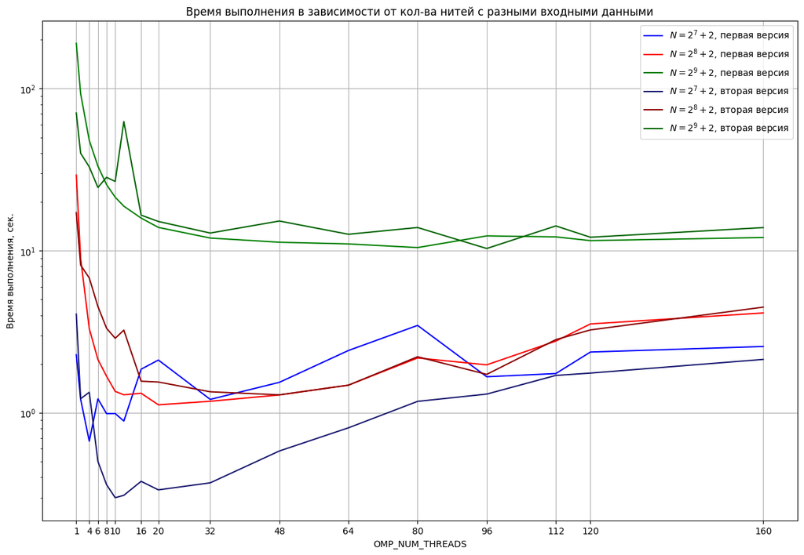

```python
tasks_1()
```

Наблюдения: 1) На небольших размерах входных данных ($N = 2^7 + 2$)значительно лучше себя показывает вторая версия. На данных побольше вторая версия чуть-чуть похуже; впрочем, это можно списать на погрешность измерений и производительности работы кластера.  
2) Результаты имеют сильный разброс, хотя при оценивании использовалось среднее значение нескольких измерений. Возможно, это связано с достаточно малым количеством задач (их примерно $N$).  
3) Точно с этой причиной связан рост времени выполнения программы при росте числа нитей на малых данных. Накладные расходы становятся слишком большими, чтобы стоить того.  
4) Замечу, что на моём локальном ноутбуке вторая версия работала на 1-8 нитях значительно лучше, чем первая; даже несколько лучше, чем программа с parallel for. Возможно, на кластере Polus измерения почему-то исказились.

# OpenMP. Сравнение версий с parallel for и на основе task'ов

Совместим графики версий с parallel for и с task'ами. Среди вариантов через task выбираю матричный, потому что его измерения более стабильны и более похожи на правду.

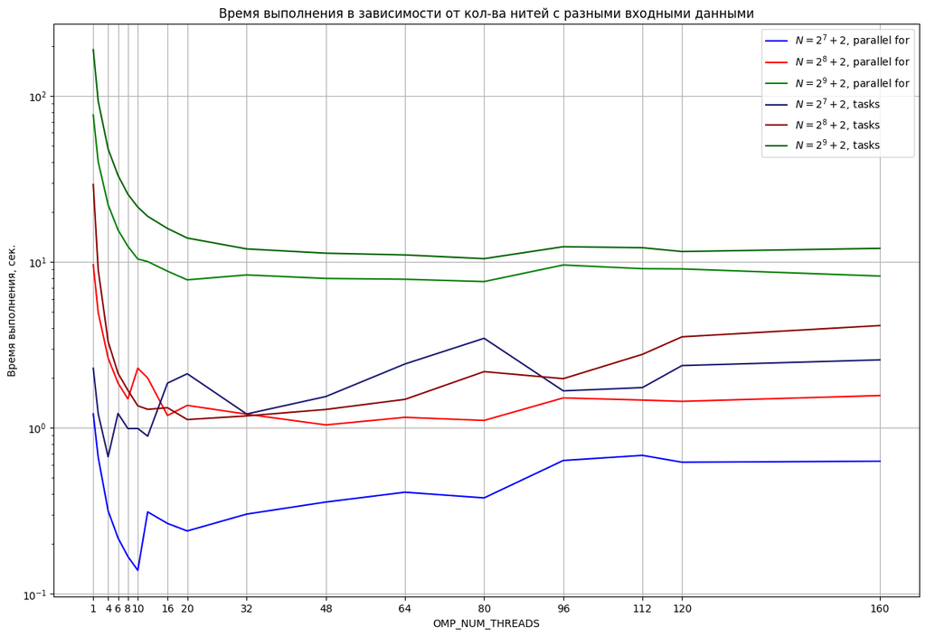

```python
tasks_2()
```

Вывод: parallel for даёт результат лучше, чем task.  
Это довольно логично, потому что в task нужно практически вручную разделять вычисления на нити, а parallel for умеет самостоятельно разделять программу по нитям оптимальным образом. Кроме того, в нём можно простым образом явно использовать редукцию операции `Max` на переменную `eps`.

# MPI

```
#include <math.h>
#include <stdlib.h>
#include <stdio.h>
#include <time.h>
#include <mpi.h>
#include <time.h>
#define  Max(a,b) ((a)>(b)?(a):(b))

#define  N   (2*2*2*2*2*2*2*2+2)
float maxeps = 0.1e-7;
int itmax = 100;
int i, j, k, i_start, i_end, slice;
int processes, pid;
float eps;
float * A, * B, * A_outer, * B_outer;
struct timespec start, end;
MPI_Request req_send[2], req_recv[2];
MPI_Status stat[2];

void relax();
void resid();
void init();
void verify();

int main(int an, char **as)
{
    int it;
    MPI_Init(&an, &as);
    MPI_Comm_size(MPI_COMM_WORLD, &processes);
    MPI_Comm_rank(MPI_COMM_WORLD, &pid);
    init();
    clock_gettime(CLOCK_REALTIME, &start);
    for(it=1; it<=itmax; it++)
    {
        eps = 0.;
        relax();
        resid();
        // if (pid == 0)
        //  printf("it=%4i   eps=%f\n", it, eps);
        if (eps < maxeps) break;
    }
    verify();
    MPI_Barrier(MPI_COMM_WORLD);
    clock_gettime(CLOCK_REALTIME, &end);
    double timespan = end.tv_sec + (double)end.tv_nsec / 1000000000 - start.tv_sec - (double)start.tv_nsec / 1000000000;
    if (pid == 0)
        printf("Elapsed time: %lf\nUsed processes: %d\n", timespan, processes);
    free(A_outer);
    free(B_outer);
    MPI_Finalize();
    return 0;
}

void init()
{
    i_start = round((float)N / processes * pid); // start of process' slice
    i_end = round((float)N / processes * (pid + 1)); // start of the next process' slice
    slice = i_end - i_start;
    A_outer = malloc(sizeof(float) * N*N*(slice+4)); // allows to address below and above A and B for received layers
    B_outer = malloc(sizeof(float) * N*N*(slice+4));
    A = A_outer + N*N*2;
    B = B_outer + N*N*2;
    for(i = 0; i < slice; i++)
    for(j = 0; j < N; j++)
    for(k = 0; k < N; k++)
    {
        if((i + i_start) == 0  || (i + i_start) == N-1 || j == 0  || j == N-1 || k == 0 || k == N-1) A[N*N*i + N*j + k] = 0.;
        else A[N*N*i + N*j + k] = ( 4. + (i + i_start) + j + k);
    }
}

void relax() // Assuming that N >= 2*processes
{
    int local_i_start = pid == 0 ? 2 : 0, local_i_end = pid == processes - 1 ? slice-2 : slice;

    if (processes > 1) {
        // sending our border layers to neighbors
        if (pid != 0)
            MPI_Isend(A, N*N*2, MPI_FLOAT, pid-1, 0, MPI_COMM_WORLD, &req_send[0]);
        if (pid != processes - 1)
            MPI_Isend(A + N*N*(slice-2), N*N*2, MPI_FLOAT, pid+1, 0, MPI_COMM_WORLD, &req_send[1]);

        // and receiving their from them
        if (pid != 0)
            MPI_Irecv(A - N*N*2, N*N*2, MPI_FLOAT, pid-1, 0, MPI_COMM_WORLD, &req_recv[0]);
        if (pid != processes - 1)
            MPI_Irecv(A + N*N*slice, N*N*2, MPI_FLOAT, pid+1, 0, MPI_COMM_WORLD, &req_recv[1]);

        // we need received values for relaxing
        if (pid == 0)
            MPI_Wait(&req_recv[1], &stat[0]);
        else if (pid == processes - 1)
            MPI_Wait(&req_recv[0], &stat[1]);
        else
            MPI_Waitall(2, req_recv, stat);
    }

    for(i = local_i_start; i < local_i_end; i++)
    for(j = 2; j < N-2; j++)
    for(k = 2; k < N-2; k++)
    {
        B[N*N*i + N*j + k]=(A[N*N*(i-1) + N*j + k] + A[N*N*(i+1) + N*j + k] + A[N*N*i + N*(j-1) + k] + A[N*N*i + N*(j+1) + k] +
                            A[N*N*i + N*j + k-1]  +  A[N*N*i + N*j + k+1]  +  A[N*N*(i-2) + N*j + k] + A[N*N*(i+2) + N*j + k] +
                            A[N*N*i + N*(j-2) + k] + A[N*N*i + N*(j+2) + k] + A[N*N*i + N*j + k-2]  +  A[N*N*i + N*j + k+2]) / 12.;
        // B[i][j][k]=(A[i-1][j][k] + A[i+1][j][k] + A[i][j-1][k] + A[i][j+1][k] + A[i][j][k-1] + A[i][j][k+1]+
        //  A[i-2][j][k] + A[i+2][j][k] + A[i][j-2][k] + A[i][j+2][k] + A[i][j][k-2] + A[i][j][k+2])/12.;
    }

    // we will change A matrix so we have to finish sending by now
    if (processes > 1)
    if (pid == 0) {
        MPI_Wait(&req_send[1], &stat[0]);
    } else if (pid == processes - 1) {
        MPI_Wait(&req_send[0], &stat[1]);
    } else {
        MPI_Waitall(2, req_send, stat);
    }
}

void resid()
{
    int local_i_start = pid == 0 ? 1 : 0, local_i_end = pid == processes - 1 ? slice-1 : slice;
    for(i = local_i_start; i < local_i_end; i++)
    for(j = 1; j < N-1; j++)
    for(k = 1; k < N-1; k++)
    {
        float e;
        e = fabs(A[N*N*i + N*j + k] - B[N*N*i + N*j + k]);
        A[N*N*i + N*j + k] = B[N*N*i + N*j + k];
        eps = Max(eps,e);
    }

    float global_eps;
    MPI_Allreduce(&eps, &global_eps, 1, MPI_FLOAT, MPI_MAX, MPI_COMM_WORLD);
    eps = global_eps;
    MPI_Barrier(MPI_COMM_WORLD);
}

void verify()
{
    double s = 0.;
    for(i = 0; i < slice; i++)
    for(j = 0; j < N; j++)
    for(k = 0; k < N; k++)
    {
        s += (double)A[N*N*i + N*j + k]*(i + i_start + 1)*(j + 1)*(k + 1)/(N*N*N);
    }
    double global_s;
    MPI_Allreduce(&s, &global_s, 1, MPI_DOUBLE, MPI_SUM, MPI_COMM_WORLD);
    if (pid == 0)
        printf("  S = %lf\n", global_s);
}
```

Программа на MPI ощутимо отличается от значальной последовательной версии. Матрицы А и В (представляющие собой трёхмерные "кубики") разбиваются по одной из осей (она итерируется переменной `i`, так что назовём её осью i) на примерно одинаковые слои, обрабатывающиеся независимо друг от друга.  
Однако простого разбиения недостаточно. Для вычисления элемента `B[i][j][k]` на очередном вызове `relax()` используются его "соседи" по каждой из осей на 2 элемента в каждую сторону, в том числе и по оси i, поэтому каждый процесс должен получить по одному крайнему слою части матрицы А размером 2xNxN от ближайших соседей. Это делается при помощи обменов "точка-точка", реализованных функциями `MPI_Isend()` и `MPI_IRecv()`.  
Для удобства адресации полученных от других процессов слоёв в функции `init()` под участки матрицы выделяется такая "подложка", чтобы в ней находились и умещались и "свои" данные процесса, и полученные извне.  
Поскольку алгоритмически мы можем одновременнно и передавать два своих слоя, и получать по слою от каждого из двух соседей, выбраны неблокирующие передачи. Перед тем, как изменять переданный слой (в функции `resid()`), нужно убедиться, что передача закончена; прежде чем пользоваться присланными нам слоями от соседей, нужно убедиться в том, что они действительно дошли до нас. Для этого вызываются функции `MPI_Wait()` и `MPI_Waitall()`.  
В функции `resid()` каждый процесс самостоятельно вычисляет свой `eps`, а затем с помощью групповой операции `MPI_Allreduce()` проводится редукция, и все процессы получают себе наибольший из их `eps`-ов. Это одна из вещей, обеспечивающих децентрализованность алгоритма - все процессы знают результат работы алгоритма, но работают только со своим куском матрицы.  
Аналогичная редукция проводится в функции `verify()` по отношению к переменной `s`. В изначальном коде она имела тип `float` (32 бит), однако этого было недостаточно: в зависимости от числа процессов выдаваемое значение тоже было разным, ошибка начиналась в пятой слева цифре. Точности сильно недоставало. Поэтому выбран тип `double` (64 бит), обеспечивающий точность примерно до 15 цифр, чего уже достаточно.  
При компиляции используется уровень оптимизации -O3.

На системе Polus проведён замер времени работы алгоритма в зависимости от размера входных данных (значения $N$). Стоит заметить, что программа требует, чтобы выполнялось $2\cdot np <= N$, где $np$ - число процессов, а $N$ - размер одного измерения матрицы. Это вызвано тем, что каждый процесс должен получить по два слоя (размером NxN) с каждой стороны, и реализация этого в предположении, что какие-то процессы могут иметь у себя лишь один слой, то есть, кусок данных размером 1xNxN, была бы, во-первых, довольно запутанной, во-вторых, бессмысленной, так как накладные расходы были бы слишком большими; проще запустить программу на меньшем числе процессов. Построим графики зависимости времени выполнения от числа процессов (и тем докажем моё утверждение по поводу бессмысленности). Шкала по оси y логарифмирована.

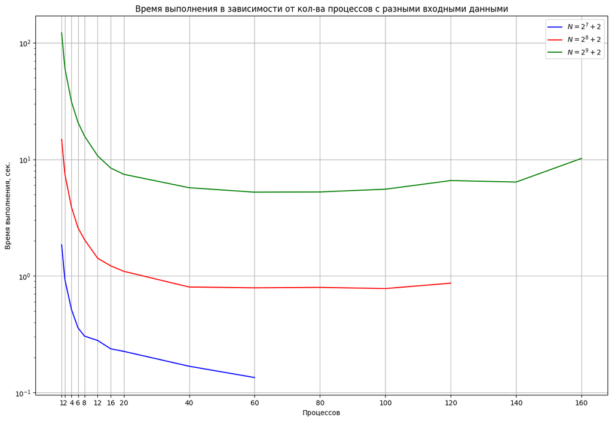

```python
mpi()
```

Выводы: алгоритм неплохо распараллеливается. До 20 процессов время выполнения почти обратно пропорционально числу процессов. Дальше время держится почти постоянным - это вызвано тем, что один вычислительный узел Polus содержит как раз 20 ядер. Некоторое ускорение всё же есть до определённой поры - например, при $N = 2^8 + 2$ разница между 20 и 40 процессами хорошо видна. Полагаю, это вызвано тем, что во время ожидания завершения обменов процессы могут простаивать, и в это время другие процессы могут проводить свои вычисления. Однако такие эффекты в данном алгоритме проявляются слабо.  
Тем не менее, при $N = 2^8 + 2$ и $N = 2^9 + 2$ хорошо видна точка насыщения (40-60 процессов), после которой наращивание числа процессов либо бесполезно, либо даже ухудшает ситуацию. Это подтверждает мой тезис о бессмысленности наращивания процессов дальше $\frac{N}{2}$ штук, так как эти точки насыщения расположены раньше.  
$N = 2^7 + 2$ слишком мало, чтобы там эти эффекты проявлялись так явно.

# Сравнение OpenMPI и MPI

Сравним время работы программ в зависиммости от входных данных и числа процессов/нитей на OpenMP (берётся версию с parallel for как наиболее успешную) и на MPI. Построим график. Шкала по оси y логарифмирована.

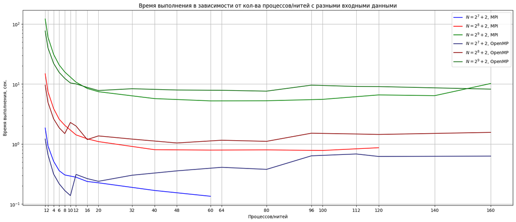

```python
openmp_vs_mpi()
```

Вывод: на малом числе процессов/нитей OpenMP имеет некое преимущество, после чего начинает уступать MPI.  
Возможно, это связано с особенностями вычислительной системы Polus (потому что замеры с OpenMP довольно странно колеблются).  
Другая версия - связано это с тем, что каждый MPI-процесс работает на своём ядре и со своим локализованным куском массива, что позволяет очень удачно использовать кэш ядра. В случае же OpenMP все нити работают в одном процессе и имеют общую память, а из-за того, что действия нитей OpenMP напрямую не контролируются, они могут быть недостаточно локализованы по памяти, и некоторое время будут терять на подгрузке элементов массива из оперативной памяти.